```r
library(tidyverse)
library(nycflights13)
```

# Lecture 05

In this notebook, we cover:

- Grouping for mutate and filter
- Pipes ([§5.6.1](http://r4ds.had.co.nz/transform.html#combining-multiple-operations-with-the-pipe))
- Summary of §5
- Visualizing distributions ([§7](http://r4ds.had.co.nz/exploratory-data-analysis.html))

## Grouped mutates and filters

```r
flights %>% group_by(month, day) %>% filter(rank(desc(dep_delay)) <= 5) %>% print
```

```
# A tibble: 1,806 x 19
# Groups:   month, day [365]
    year month   day dep_t… sched_… dep_d… arr_… sched… arr_… carr… flig… tail…
   <int> <int> <int>  <int>   <int>  <dbl> <int>  <int> <dbl> <chr> <int> <chr>
 1  2013     1     1    848    1835    853  1001   1950   851 MQ     3944 N942…
 2  2013     1     1   1815    1325    290  2120   1542   338 EV     4417 N171…
 3  2013     1     1   1842    1422    260  1958   1535   263 EV     4633 N181…
 4  2013     1     1   2205    1720    285    46   2040   246 AA     1999 N5DN…
 5  2013     1     1   2343    1724    379   314   1938   456 EV     4321 N211…
 6  2013     1     2   1244     900    224  1431   1104   207 EV     4412 N139…
 7  2013     1     2   1332     904    268  1616   1128   288 EV     4364 N411…
 8  2013     1     2   1412     838    334  1710   1147   323 UA      468 N474…
 9  2013     1     2   1607    1030    337  2003   1355   368 AA      179 N324…
10  2013     1     2   2131    1512    379  2340   1741   359 UA      488 N593…
# ... with 1,796 more rows, and 7 more variables: origin <chr>, dest <chr>,
#   air_time <dbl>, distance <dbl>, hour <dbl>, minute <dbl>, time_hour <dttm>
```

```r
flights %>% group_by(month, day) %>% top_n(5, dep_delay) %>% print
```

```
# A tibble: 1,844 x 19
# Groups:   month, day [365]
    year month   day dep_t… sched_… dep_d… arr_… sched… arr_… carr… flig… tail…
   <int> <int> <int>  <int>   <int>  <dbl> <int>  <int> <dbl> <chr> <int> <chr>
 1  2013     1     1    848    1835    853  1001   1950   851 MQ     3944 N942…
 2  2013     1     1   1815    1325    290  2120   1542   338 EV     4417 N171…
 3  2013     1     1   1842    1422    260  1958   1535   263 EV     4633 N181…
 4  2013     1     1   2205    1720    285    46   2040   246 AA     1999 N5DN…
 5  2013     1     1   2343    1724    379   314   1938   456 EV     4321 N211…
 6  2013     1     2   1244     900    224  1431   1104   207 EV     4412 N139…
 7  2013     1     2   1332     904    268  1616   1128   288 EV     4364 N411…
 8  2013     1     2   1412     838    334  1710   1147   323 UA      468 N474…
 9  2013     1     2   1607    1030    337  2003   1355   368 AA      179 N324…
10  2013     1     2   2131    1512    379  2340   1741   359 UA      488 N593…
# ... with 1,834 more rows, and 7 more variables: origin <chr>, dest <chr>,
#   air_time <dbl>, distance <dbl>, hour <dbl>, minute <dbl>, time_hour <dttm>
```

A grouped mutate acts similarly. Any aggregate functions like `sum()` or `n()` are evaluated over their respective subgroups. The following commands compute the proportion of each carrier's total annual attributable to each flight.

```r
flights %>% group_by(carrier) %>% filter(dep_delay > 0) %>%
            mutate(prop_delay = dep_delay / sum(dep_delay)) %>%
            select(carrier, month, day, dep_delay, prop_delay) %>% print
```

```
# A tibble: 128,432 x 5
# Groups:   carrier [16]
   carrier month   day dep_delay prop_delay
   <chr>   <int> <int>     <dbl>      <dbl>
 1 UA          1     1      2.00 0.00000245
 2 UA          1     1      4.00 0.00000490
 3 AA          1     1      2.00 0.00000530
 4 B6          1     1      1.00 0.00000117
 5 MQ          1     1      8.00 0.0000222
 6 UA          1     1     11.0  0.0000135
 7 B6          1     1      3.00 0.00000352
 8 AA          1     1     13.0  0.0000344
 9 EV          1     1     24.0  0.0000206
10 UA          1     1      8.00 0.00000981
# ... with 128,422 more rows
```

## Pipes

In chapter 5 we have made extensive use of the pipe operator `%>%` to wire together the `select()`, `arrange()`, `filter()`, and `mutate()` commands. Here's one such example from the last lecture:

```r
library(lubridate)  # Find how many red-eye flights there are for each day of the week
flights %>% filter(!is.na(arr_time) & !is.na(dep_time)) %>%
            mutate(date=ISOdate(year, month, day), day_of_week=wday(date, label=T)) %>%
            group_by(day_of_week) %>%
            summarize(n_redeye=sum(dep_time > arr_time)) %>%
            arrange(desc(n_redeye)) %>% print
```

```
# A tibble: 7 x 2
  day_of_week n_redeye
  <ord>          <int>
1 Sun             1766
2 Thu             1726
3 Mon             1687
4 Fri             1670
5 Wed             1485
6 Tue             1367
7 Sat              932
```

```r
# option 1
filter(
    arrange(
        mutate(
            group_by(
                summarize(
                    group_by(flights, carrier, month),
                    mean_dep_delay=mean(dep_delay, na.rm=T)),
                month),
        rank=min_rank(-mean_dep_delay)), month, rank),
    rank==1)
```

```
   carrier month mean_dep_delay rank
1  OO       1    67.00000       1
2  F9       2    29.77083       1
3  YV       3    31.88889       1
4  YV       4    27.11111       1
5  F9       5    35.94828       1
6  OO       6    61.00000       1
7  FL       7    41.16270       1
8  OO       8    64.00000       1
9  FL       9    16.94882       1
10 YV      10    20.00000       1
11 FL      11    16.86634       1
12 EV      12    27.88718       1
```

```r
# option 2
new_table = group_by(flights, carrier, month)
new_table1 = summarize(new_table, mean_dep_delay = mean(dep_delay, na.rm = T))
new_table2 = group_by(new_table1, month)
new_table3 = mutate(new_table2, rank = min_rank(-mean_dep_delay))
new_table4 = arrange(new_table3, month, rank)
new_table5 = filter(new_table4, rank == 1)
new_table5
```

```
   carrier month mean_dep_delay rank
1  OO       1    67.00000       1
2  F9       2    29.77083       1
3  YV       3    31.88889       1
4  YV       4    27.11111       1
5  F9       5    35.94828       1
6  OO       6    61.00000       1
7  FL       7    41.16270       1
8  OO       8    64.00000       1
9  FL       9    16.94882       1
10 YV      10    20.00000       1
11 FL      11    16.86634       1
12 EV      12    27.88718       1
```

Hopefully these examples convince you of the utility of `%>%`:

In summary, both these alternatives are messier and more error-prone.

### How `%>%` works

Under the hood, `x %>% f(y)` turns into `f(x, y)`, and `x %>% f(y) %>% g(z)` turns into `g(f(x, y), z)` and so on. We can use `%>%` on any function, not just those defined in tidyverse:

```r
2 %>% `*`(3)  # same as `*`(2,3) = 2 * 3
3 %>% `+`(4) %>% `*`(5)  # 5 * (3 + 4) = 35 -- _not_ 3 + (4 * 5) = 23
(4) %>% `*`(5) %>% `+`(3)
```

```
[1] 6
```

```
[1] 35
```

```
[1] 23
```

**Note** that chaining the `%>%` operator evaluates left-to-right. This is the natural order for data processing pipelines.

### Using `.` with pipe

By default the pipe inserts the output of the LHS command as the first argument to the RHS command:

```
{r}
f() %>% g()  # same as g(f())
```

If you need to use the LHS output elsewhere in the command, the `.` character can be used to place it there:

```
{r}
f() %>% g(1, .)  # same as g(1, f())
```

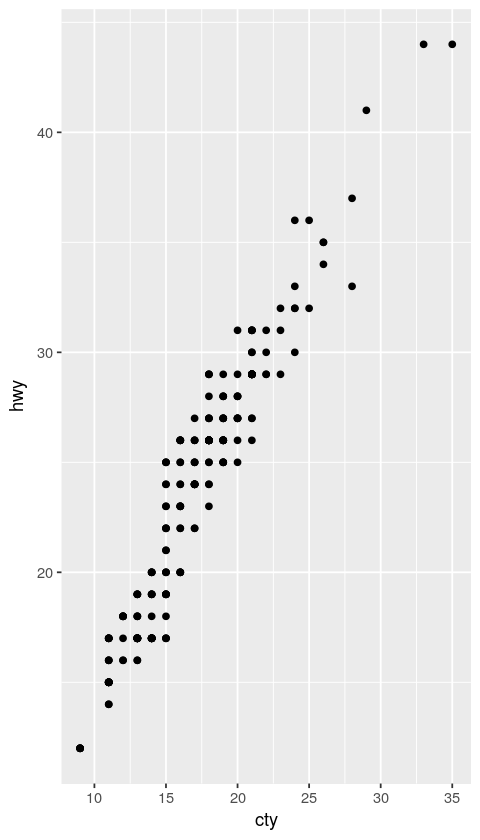

```r
mpg %>% ggplot(mapping=aes(x=cty, y=hwy), data=.) + geom_point()
```

### The `%$%` operator

A related operator is `%$%`. This is used to extract a column given by the RHS from the data table on the LHS. This is not loaded standard in `tidyverse`; you must load it separately in the `magrittr` library.

```r
library(magrittr)
flights %$% arr_time %>% head
# equivalently
flights %>% .[,'arr_time'] %>% head
```

```
[1]  830  850  923 1004  812  740
```

```
  arr_time
1  830
2  850
3  923
4 1004
5  812
6  740
```

## Summary of §5

- `filter()`: drop rows from a data table based on certain logical conditions.
- `select()`: keep *columns* in a data table by name, range, or logical conditions.
- `arrange()`: sort / reorder the rows of a data table.
- `mutate()`: generate new columns in a data table by applying functions to the existing ones.
- `group_by()` / `summarize()`: group rows together based on one or more variables, and compute summary statistics within each group.

### Frequently encountered questions

Here are a couple of specific issues that arose in OH and on Canvas:

#### `filter()` vs `select()`

Some students were mixing up the use of `filter()` and `select()`.

#### Filter

`filter()` selects rows:

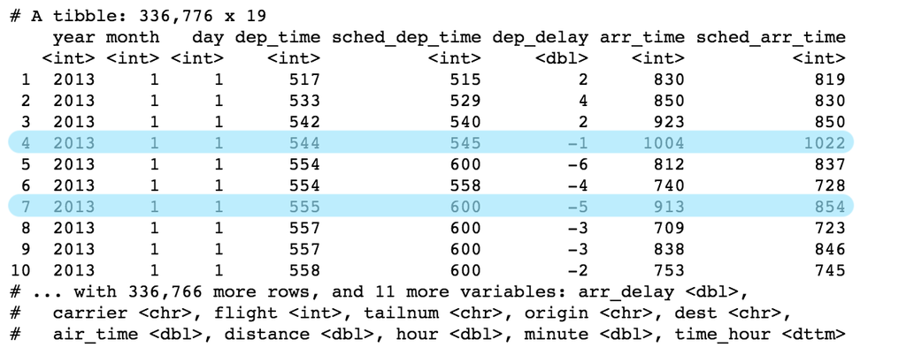

#### Select

`select()` selects columns

[figure not shown]

#### When to quote

Columns should not be quoted inside of commands like `filter()`. The following command returns an empty data table. Why? Because the condition evaluates to `FALSE`, which is then recycled up to every row of the table:

```r
filter(flights, "carrier" == "UA") %>% print  # wrong: compares the string "carrier" to the string "UA"
# filter(flights, carrier == UA) produces an error: compares the column carrier to the (nonexistent) column UA
# correct: filter(flights, carrier == "UA")
```

```
# A tibble: 0 x 19
# ... with 19 variables: year <int>, month <int>, day <int>, dep_time <int>,
#   sched_dep_time <int>, dep_delay <dbl>, arr_time <int>,
#   sched_arr_time <int>, arr_delay <dbl>, carrier <chr>, flight <int>,
#   tailnum <chr>, origin <chr>, dest <chr>, air_time <dbl>, distance <dbl>,
#   hour <dbl>, minute <dbl>, time_hour <dttm>
```

#### `=` versus `==`

Remember that `=` and `==` mean different things. The former is used for assignment and to pass keyword parameters to functions. The latter is used to test for equality and returns either `TRUE` or `FALSE`.

```r
mutate(flights, carrier == "UA") %>% select(ncol(flights) + 1) %>% print
# filter(flights, carrier = "UA")  ## error
```

```
# A tibble: 336,776 x 1
   `carrier == "UA"`
   <lgl>
 1 T
 2 T
 3 F
 4 F
 5 F
 6 T
 7 F
 8 F
 9 F
10 F
# ... with 336,766 more rows
```

#### Vector versus column versus data table

There is particular confusion about when it is appropriate to use vectors, columns and data tables. We will be discussing these concepts at greater length in the coming weeks, but here are some essentials that you should know:

**Vectors** in R contain multiple values. You create vectors using the `c()` function. If you do neglect to do this, R will produce an error and/or do the wrong thing. Some examples of this I saw include:

```
{r}
a = factor(b, levels=1, 2, 3, 4, 5) ## wrong
a = factor(b, levels=(1, 2, 3, 4, 5)) ## wrong
a = factor(b, levels=c(1, 2, 3, 4, 5)) ## correct
```

Vectors have a particular type, and all the entries of the vector must be of that same type; if they are not R will convert them to be.

```r
c(1,2,'a')  # conversion to string
c(T, T, factor('a'))  # conversion to int
```

```
[1] "1" "2" "a"
```

```
[1] 1 1 1
```

You can think of a data table as a list of vectors. Each column has its own vector. To access a vector of values stored in a column in R, we traditionally use the `$` operator:

```r
head(flights$arr_time)
```

```
[1]  830  850  923 1004  812  740
```

If working inside one of the `dplyr` functions like `mutate()`, `filter()`, etc., the dataset is specified by the first parameter. So you don't need to use the `$` operator, just specify the column name:

```
{r}
filter(flights, flights$arr_delay < 10)  # wrong (although it will work)
filter(flights, arr_delay < 10)  # correct
```

Even though they contain the same information, a column vector is *not the same* as a table containing only that column:

```r
head(flights$arr_time)  # <---- vector
# is different from...
head(select(flights, arr_time)) # <---- data table
```

```
[1]  830  850  923 1004  812  740
```

```
  arr_time
1  830
2  850
3  923
4 1004
5  812
6  740
```

Passing in a data table where R expects a vector will lead to errors. For example, neither of the following are valid:

```
{r}
month_factor = factor(flights)
month_factor = factor(select(flights, month))
```

These will take a large amount of time to run because R is creating a huge factor, one with a level for every observation in your data table.

### Some worked examples

Finally, we'll work through a few examples of how to put all of this together.

#### Plot the on-time percentage by month for each airline

```r
ot = flights %>% mutate(on_time=arr_delay <= 0) %>% select(month, carrier, on_time) %>% print
```

```
# A tibble: 336,776 x 3
   month carrier on_time
   <int> <chr>   <lgl>
 1     1 UA      F
 2     1 UA      F
 3     1 AA      F
 4     1 B6      T
 5     1 DL      T
 6     1 UA      F
 7     1 B6      F
 8     1 EV      T
 9     1 B6      T
10     1 AA      F
# ... with 336,766 more rows
```

```r
ot = ot %>% group_by(carrier, month) %>%
            summarize(on_time_pct=mean(on_time, na.rm=T), n=n()) %>% print
```

```
# A tibble: 185 x 4
# Groups:   carrier [?]
   carrier month on_time_pct     n
   <chr>   <int>       <dbl> <int>
 1 9E          1       0.578  1573
 2 9E          2       0.597  1459
 3 9E          3       0.674  1627
 4 9E          4       0.632  1511
 5 9E          5       0.607  1462
 6 9E          6       0.522  1437
 7 9E          7       0.512  1494
 8 9E          8       0.615  1456
 9 9E          9       0.749  1540
10 9E         10       0.677  1673
# ... with 175 more rows
```

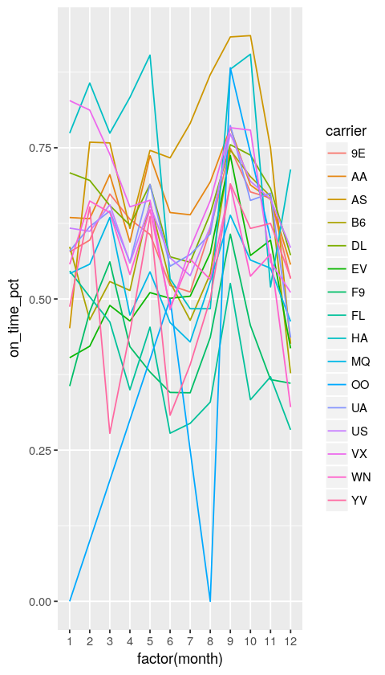

```r
ot %>% ggplot(aes(x=factor(month), y=on_time_pct, group=carrier, color=carrier)) +
       geom_line()
```

This is what we want, but is too busy. Let's filter down to only the carriers that have a pretty high number of observations.

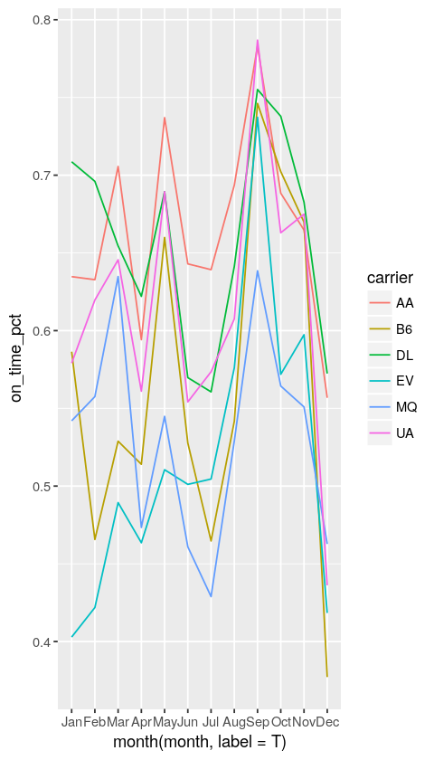

```r
ot %>% filter(n > 2000) %>%
       ggplot(aes(x=month(month, label=T), y=on_time_pct, group=carrier, color=carrier)) +
       geom_line()
```

Finally, let's make the axis labels more readable.

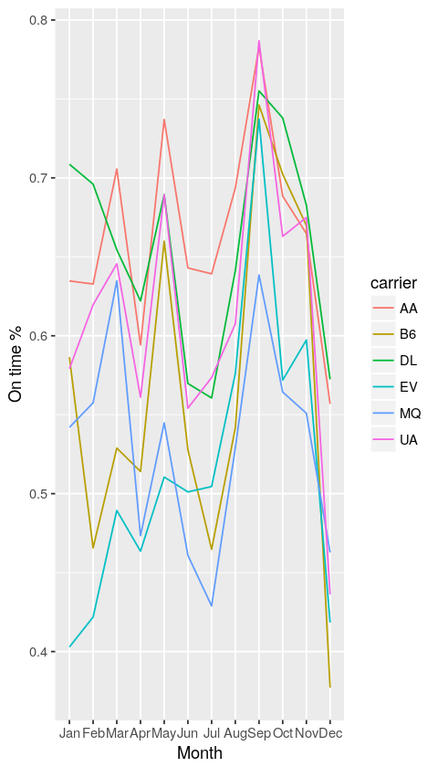

```r
ot %>% filter(n > 2000) %>%
       ggplot(aes(x=month(month, label=T), y=on_time_pct, group=carrier, color=carrier)) +
       geom_line() + xlab('Month') + ylab("On time %")
```

#### Restrict to the top $k$ airlines

```r
top_flights = flights %>% group_by(carrier) %>% count %>% arrange(n) %>% ungroup() %>%
              mutate(cd=cumsum(n)/sum(n)) %>% print
```

```
# A tibble: 16 x 3
   carrier     n        cd
   <chr>   <int>     <dbl>
 1 OO         32 0.0000950
 2 HA        342 0.00111
 3 YV        601 0.00290
 4 F9        685 0.00493
 5 AS        714 0.00705
 6 FL       3260 0.0167
 7 VX       5162 0.0321
 8 WN      12275 0.0685
 9 9E      18460 0.123
10 US      20536 0.184
11 MQ      26397 0.263
12 AA      32729 0.360
13 DL      48110 0.503
14 EV      54173 0.664
15 B6      54635 0.826
16 UA      58665 1.00
```

## Visualizing distributions

Recall that a **categorical** variable is one that can only take one of a (small) finite number of values. For example, in the `diamonds` data set, `color` is a categorical variable.

```r
print(diamonds)
```

```
# A tibble: 53,940 x 10
   carat cut       color clarity depth table price     x     y     z
   <dbl> <ord>     <ord> <ord>   <dbl> <dbl> <int> <dbl> <dbl> <dbl>
 1 0.230 Ideal     E     SI2      61.5  55.0   326  3.95  3.98  2.43
 2 0.210 Premium   E     SI1      59.8  61.0   326  3.89  3.84  2.31
 3 0.230 Good      E     VS1      56.9  65.0   327  4.05  4.07  2.31
 4 0.290 Premium   I     VS2      62.4  58.0   334  4.20  4.23  2.63
 5 0.310 Good      J     SI2      63.3  58.0   335  4.34  4.35  2.75
 6 0.240 Very Good J     VVS2     62.8  57.0   336  3.94  3.96  2.48
 7 0.240 Very Good I     VVS1     62.3  57.0   336  3.95  3.98  2.47
 8 0.260 Very Good H     SI1      61.9  55.0   337  4.07  4.11  2.53
 9 0.220 Fair      E     VS2      65.1  61.0   337  3.87  3.78  2.49
10 0.230 Very Good H     VS1      59.4  61.0   338  4.00  4.05  2.39
# ... with 53,930 more rows
```

Say we are interested in the distribution of the `color`. We can plot a bar chart to visualize this:

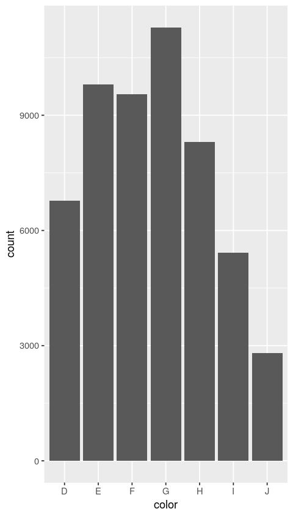

```r
ggplot(data = diamonds) +
    geom_bar(mapping = aes(x = color))
```

Here ggplot has done some work for us: it has grouped the data by color, summarized it, and plotted a bar graph of the result. Let's reproduce this ourselves using the knowledge we have gained from §5:

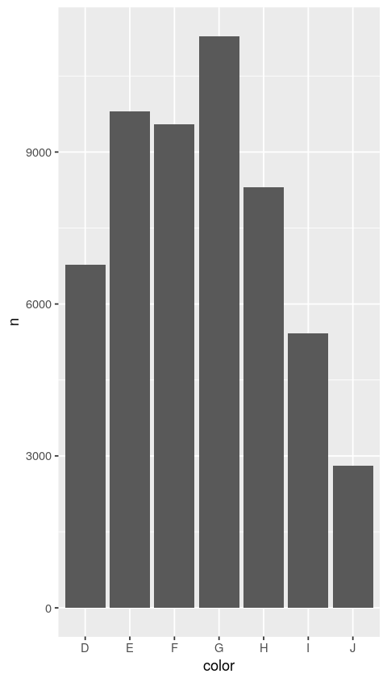

```r
count(diamonds, color) %>% ggplot(aes(x=color, y=n)) + geom_col()
```

A **continuous** variable can take one of an infinite number of ordered values. Let us look at the **dep_delay** variables from the `flights` data set. Note that we are about to use a new ggplot geometry, namely **geom_histogram**. It can be used to visualize the distribution of a continuous variable.

```
Warning message:
“Removed 8255 rows containing non-finite values (stat_bin).”
```

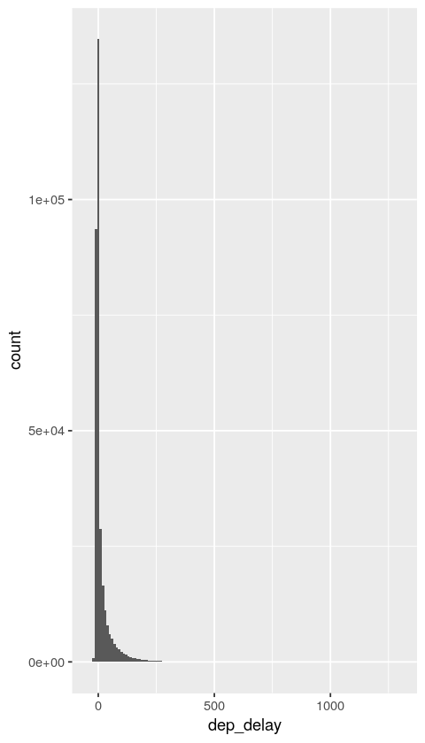

```r
library(nycflights13)
    ggplot(data = flights) +
        geom_histogram(mapping = aes(x = dep_delay), binwidth = 10)
```

Here ggplot is warning us that 8,255 rows got dropped. We should verify that we know exactly why these rows could not be plotted:

```r
flights %>% filter(is.na(dep_delay)) %>% count()
```

```
  n
1 8255
```

Now let us work with non-missing values only.

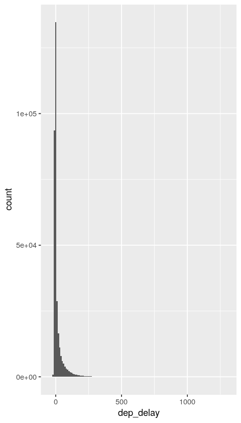

```r
flights_nona = filter(flights, !is.na(dep_delay))
ggplot(flights_nona) +
    geom_histogram(mapping = aes(x = dep_delay), binwidth = 10)
```

Let us zoom into the left part of the plot. Let us only look at flights with departure delays of less than an hour.

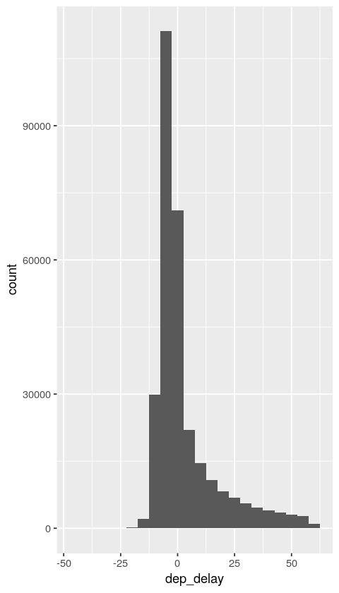

```r
flights_nona %>%
    filter(dep_delay < 60) %>%
    ggplot() +
        geom_histogram(mapping = aes(x = dep_delay), binwidth = 5) # we choose a smaller bin width now
```

We will again reproduce this plot by hand using the tools we developed earlier. The `cut_width(v, k)` function can be used to count how many observations in `v` fall into buckets of width `k`. In the preceding plot we chose a `binwidth=5` so that will be our value of `k`.

```
# A tibble: 21 x 2
   cw                 n
   <fctr>         <int>
 1 [-47.5,-42.5]      1
 2 (-37.5,-32.5]      1
 3 (-32.5,-27.5]      2
 4 (-27.5,-22.5]     14
 5 (-22.5,-17.5]    160
 6 (-17.5,-12.5]   2079
 7 (-12.5,-7.5]   29878
 8 (-7.5,-2.5]   111111
 9 (-2.5,2.5]     71126
10 (2.5,7.5]      22013
# ... with 11 more rows
```

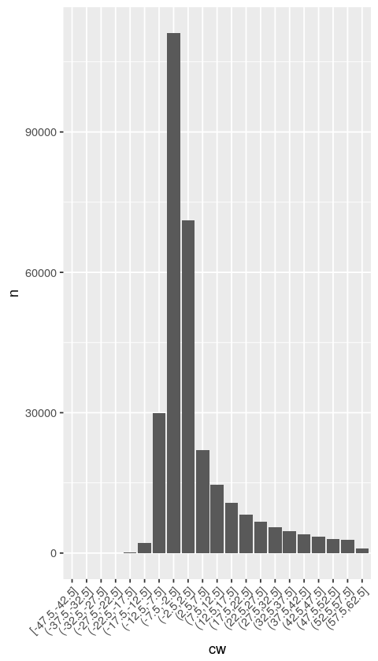

```r
flights_nona %>% filter(dep_delay < 60) %>%
    count(cw=cut_width(dep_delay, 5)) %>% print %>% ggplot(aes(x=cw, y=n)) + geom_col() +
    theme(axis.text.x = element_text(angle = 45, hjust = 1))
```

The appearance of a histogram does depend on your choice of the bin width. It is a good idea to try several values to see if different choices reveal different patterns.

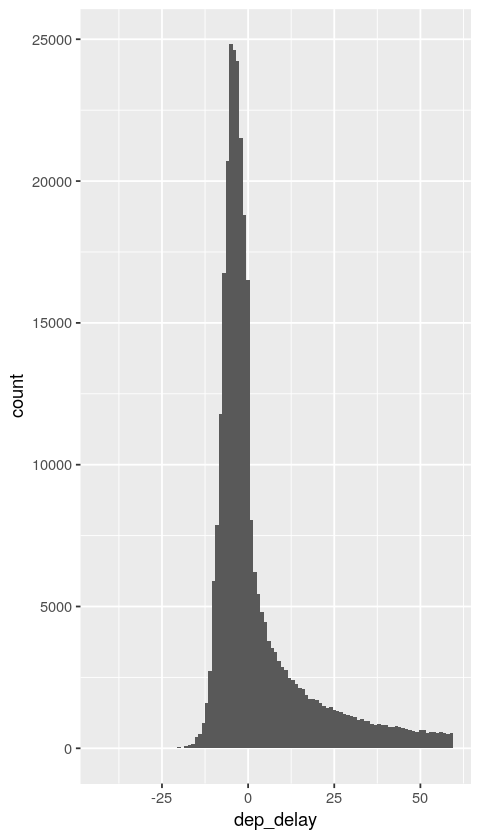

```r
flights_nona %>%
    filter(dep_delay < 60) %>%
    ggplot() +
        geom_histogram(mapping = aes(x = dep_delay), binwidth = 1) # we choose an even smaller bin width now
```

Let us bring in the categorical variable **carrier** and map the color aesthetic to it.

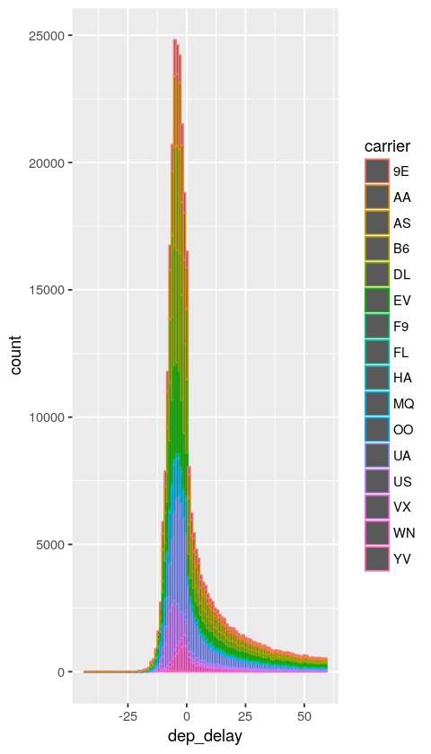

```r
flights_nona %>%
    filter(dep_delay < 60) %>%
        ggplot() +
            geom_histogram(mapping = aes(x = dep_delay, color = carrier), binwidth = 1)
```

The legend is a bit crowded. Let us see who the major carriers are by number of flights.

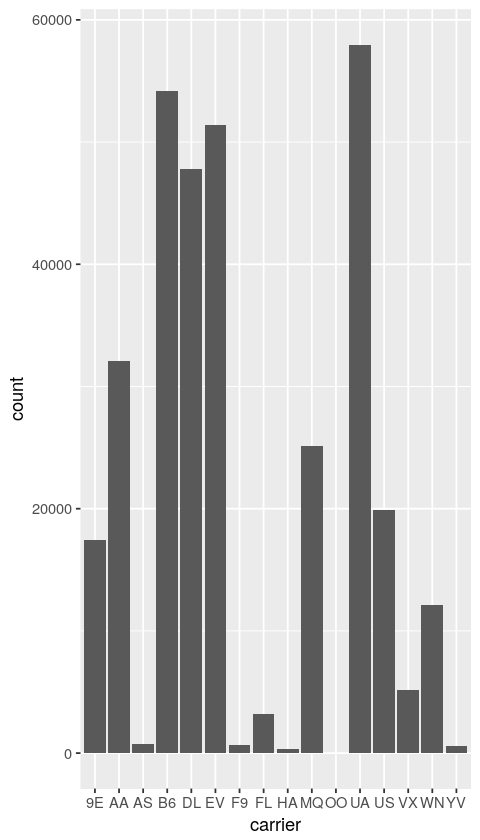

```r
flights_nona %>% ggplot() +
        geom_bar(mapping = aes(x = carrier))
```

Visually, we see that the top 5 carriers by flight count are AA, B6, DL, EV and UA. But let us compute this using pipes.

```r
library(magrittr)
(top5 <- flights_nona %>%
    group_by(carrier) %>%
    summarize(count = n()) %>%
    top_n(5, count)
    %$% carrier) # new syntax -- %$% extracts a column as an R vector
```

```
[1] "AA" "B6" "DL" "EV" "UA"
```

Now we can additionally filter out rows that do not belong to the top 5 carriers.

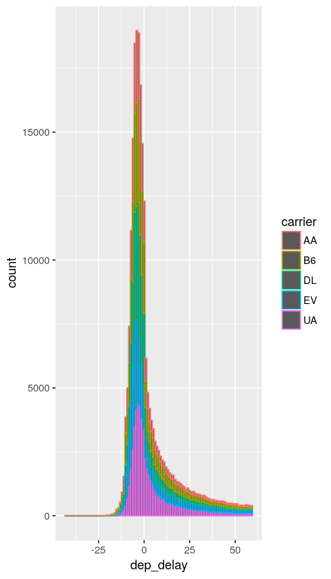

```r
flights_nona %>%
    filter(dep_delay < 60, carrier %in% top5) %>%
    ggplot() +
        geom_histogram(mapping = aes(x = dep_delay, color = carrier), binwidth = 1)
```

This is better but still not very clean. Let us use a new geometry **freqpoly** which is like histogram but shows lines. Overlapping lines are easier to see than overlapping bars.

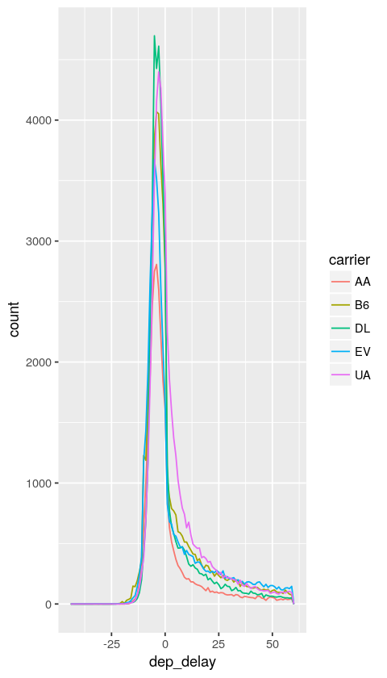

```r
flights_nona %>%
    filter(dep_delay < 60, carrier %in% top5) %>%
    ggplot() +
        geom_freqpoly(mapping = aes(x = dep_delay, color = carrier), binwidth = 1)
```

It is a bit hard to understand the above plot since UA has much more traffic than AA making a comparison of their plot shapes difficult.